# KSN_eval

## To further improve the model's performance, particularly for the missile class where recall is low, several steps can be taken:

- **Remove Noise Images:** During data preparation, ensure that images not relevant to the specific classes (noise images) are thoroughly removed. Noise images can confuse the model during training, leading to poor performance. Use techniques like manual inspection or automated anomaly detection to ensure clean datasets.
- **Data Augmentation:** Although some augmentation is already applied, experimenting with different augmentation techniques (like random rotations, flips, brightness adjustments) can help the model generalize better, particularly if the dataset is small or imbalanced.
- **Class Imbalance Handling:** If certain classes (like missile) are underrepresented, the model may struggle to learn them well. Oversampling techniques (e.g., SMOTE) or undersampling other classes can help balance the dataset and improve recall.
- **Hyperparameter Tuning:** Adjusting learning rates, batch sizes, and the architecture of the model (e.g., number of layers, dropout) may help improve generalization and accuracy.
- **Preprocessing:** Apply more thorough preprocessing such as contrast normalization, resizing, and noise reduction filters to enhance the image quality and reduce potential distractions for the model.
- **Transfer Learning:** Fine-tuning a pre-trained model on a similar domain might help improve accuracy, as the model can leverage learned features that are transferable to your problem domain.

```python
def plot_hist(history):
    hist = pd.DataFrame(history.history)
    hist['epoch'] = history.epoch

    fig = go.Figure()
    fig.add_trace(go.Scatter(x=hist['epoch'], y=hist['accuracy'], name='accuracy', mode='markers+lines'))
    fig.add_trace(go.Scatter(x=hist['epoch'], y=hist['val_accuracy'], name='val_accuracy', mode='markers+lines'))
    fig.update_layout(width=1000, height=500, title='Accuracy vs. Val Accuracy', xaxis_title='Epoki', yaxis_title='Accuracy', yaxis_type='log')
    fig.show()

    fig = go.Figure()
    fig.add_trace(go.Scatter(x=hist['epoch'], y=hist['loss'], name='loss', mode='markers+lines'))
    fig.add_trace(go.Scatter(x=hist['epoch'], y=hist['val_loss'], name='val_loss', mode='markers+lines'))
    fig.update_layout(width=1000, height=500, title='Loss vs. Val Loss', xaxis_title='Epoki', yaxis_title='Loss', yaxis_type='log')
    fig.show()
```

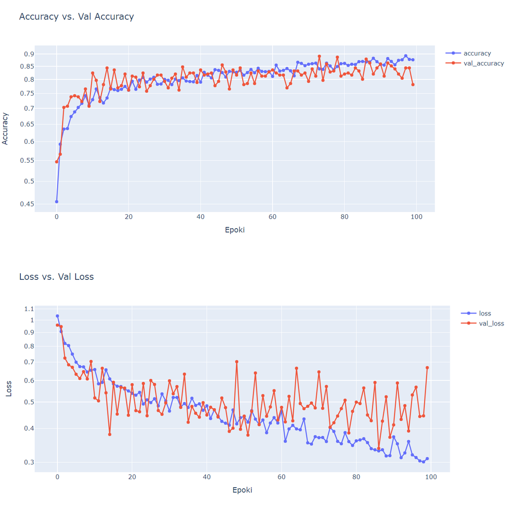

```python
test_datagen = ImageDataGenerator(rescale=1./255.)
test_generator = test_datagen.flow_from_directory(
    # sciezka dostepu
    test_dir,
    target_size=(150, 150),
    batch_size=1,
    class_mode='categorical',
    shuffle=False
)


y_prob = model.predict(test_generator, test_generator.samples)
y_prob
```

```
Found 393 images belonging to 3 classes.
```

```
array([[0.921514, 0.000212, 0.078274],
       [0.999342, 0.00004 , 0.000618],
       [0.999464, 0.000039, 0.000497],
       ...,
       [0.109283, 0.846048, 0.044669],
       [0.012306, 0.000323, 0.987371],
       [0.000693, 0.000084, 0.999223]], dtype=float32)
```

```python
y_pred = np.argmax(y_prob, axis=1)
y_pred
```

```
array([0, 0, 0, 0, 0, 0, 0, 0, 0, 0, 0, 0, 0, 0, 0, 0, 0, 0, 0, 0, 0, 0,
       0, 0, 0, 0, 0, 2, 0, 0, 0, 0, 0, 1, 0, 0, 0, 0, 0, 0, 0, 0, 0, 0,
       1, 0, 0, 0, 2, 0, 0, 0, 0, 0, 0, 0, 0, 0, 0, 2, 0, 0, 2, 0, 0, 0,
       0, 0, 0, 0, 0, 0, 0, 0, 0, 0, 0, 0, 0, 2, 0, 0, 0, 0, 0, 0, 0, 0,
       0, 0, 0, 0, 0, 0, 0, 0, 0, 0, 0, 0, 0, 0, 0, 0, 0, 0, 0, 0, 0, 0,
       0, 0, 0, 0, 0, 0, 0, 0, 0, 0, 0, 0, 0, 0, 0, 0, 0, 0, 0, 0, 0, 1,
       1, 1, 1, 1, 1, 1, 1, 1, 1, 1, 1, 1, 1, 1, 1, 1, 1, 1, 1, 1, 1, 1,
       1, 1, 1, 1, 1, 0, 1, 1, 1, 1, 1, 1, 1, 1, 1, 1, 1, 1, 1, 1, 1, 1,
       1, 1, 1, 1, 1, 1, 1, 1, 1, 1, 1, 1, 0, 1, 1, 1, 1, 1, 1, 1, 1, 1,
       1, 1, 1, 1, 1, 0, 1, 1, 1, 0, 0, 1, 1, 1, 1, 1, 1, 1, 1, 1, 1, 1,
       1, 1, 1, 1, 1, 1, 1, 1, 1, 1, 1, 1, 1, 1, 1, 1, 1, 1, 0, 1, 1, 1,
       1, 1, 1, 1, 1, 1, 1, 1, 1, 1, 1, 1, 1, 2, 0, 1, 1, 1, 0, 1, 0, 2,
       0, 2, 0, 2, 0, 2, 2, 0, 0, 2, 0, 2, 2, 2, 2, 0, 2, 2, 2, 2, 1, 1,
       1, 2, 2, 2, 0, 2, 2, 0, 2, 2, 0, 2, 0, 2, 2, 2, 2, 2, 0, 0, 2, 2,
       2, 0, 2, 2, 0, 0, 2, 1, 2, 2, 0, 2, 2, 1, 2, 2, 0, 0, 0, 0, 0, 0,
       2, 0, 2, 2, 2, 2, 0, 2, 0, 2, 2, 2, 2, 2, 2, 0, 2, 2, 2, 0, 0, 2,
       2, 2, 0, 0, 2, 2, 2, 2, 0, 0, 2, 0, 0, 2, 2, 0, 2, 2, 2, 0, 2, 2,
       2, 2, 1, 2, 0, 2, 0, 2, 0, 1, 2, 2, 2, 0, 2, 0, 1, 2, 2])
```

```python
predictions  = pd.DataFrame({'class': y_pred})
predictions
```

|  | class |
| --- | --- |
| 0 | 0 |
| 1 | 0 |
| 2 | 0 |
| 3 | 0 |
| 4 | 0 |
| ... | ... |
| 388 | 2 |
| 389 | 0 |
| 390 | 1 |
| 391 | 2 |
| 392 | 2 |

393 rows × 1 columns

```python
y_true = test_generator.classes
y_true
```

```
array([0, 0, 0, 0, 0, 0, 0, 0, 0, 0, 0, 0, 0, 0, 0, 0, 0, 0, 0, 0, 0, 0,
       0, 0, 0, 0, 0, 0, 0, 0, 0, 0, 0, 0, 0, 0, 0, 0, 0, 0, 0, 0, 0, 0,
       0, 0, 0, 0, 0, 0, 0, 0, 0, 0, 0, 0, 0, 0, 0, 0, 0, 0, 0, 0, 0, 0,
       0, 0, 0, 0, 0, 0, 0, 0, 0, 0, 0, 0, 0, 0, 0, 0, 0, 0, 0, 0, 0, 0,
       0, 0, 0, 0, 0, 0, 0, 0, 0, 0, 0, 0, 0, 0, 0, 0, 0, 0, 0, 0, 0, 0,
       0, 0, 0, 0, 0, 0, 0, 0, 0, 0, 0, 0, 0, 0, 0, 0, 0, 0, 0, 0, 0, 1,
       1, 1, 1, 1, 1, 1, 1, 1, 1, 1, 1, 1, 1, 1, 1, 1, 1, 1, 1, 1, 1, 1,
       1, 1, 1, 1, 1, 1, 1, 1, 1, 1, 1, 1, 1, 1, 1, 1, 1, 1, 1, 1, 1, 1,
       1, 1, 1, 1, 1, 1, 1, 1, 1, 1, 1, 1, 1, 1, 1, 1, 1, 1, 1, 1, 1, 1,
       1, 1, 1, 1, 1, 1, 1, 1, 1, 1, 1, 1, 1, 1, 1, 1, 1, 1, 1, 1, 1, 1,
       1, 1, 1, 1, 1, 1, 1, 1, 1, 1, 1, 1, 1, 1, 1, 1, 1, 1, 1, 1, 1, 1,
       1, 1, 1, 1, 1, 1, 1, 1, 1, 1, 1, 1, 1, 1, 1, 1, 1, 1, 1, 1, 2, 2,
       2, 2, 2, 2, 2, 2, 2, 2, 2, 2, 2, 2, 2, 2, 2, 2, 2, 2, 2, 2, 2, 2,
       2, 2, 2, 2, 2, 2, 2, 2, 2, 2, 2, 2, 2, 2, 2, 2, 2, 2, 2, 2, 2, 2,
       2, 2, 2, 2, 2, 2, 2, 2, 2, 2, 2, 2, 2, 2, 2, 2, 2, 2, 2, 2, 2, 2,
       2, 2, 2, 2, 2, 2, 2, 2, 2, 2, 2, 2, 2, 2, 2, 2, 2, 2, 2, 2, 2, 2,
       2, 2, 2, 2, 2, 2, 2, 2, 2, 2, 2, 2, 2, 2, 2, 2, 2, 2, 2, 2, 2, 2,
       2, 2, 2, 2, 2, 2, 2, 2, 2, 2, 2, 2, 2, 2, 2, 2, 2, 2, 2],
      dtype=int32)
```

```python
y_pred = predictions['class'].values
y_pred
```

```
array([0, 0, 0, 0, 0, 0, 0, 0, 0, 0, 0, 0, 0, 0, 0, 0, 0, 0, 0, 0, 0, 0,
       0, 0, 0, 0, 0, 2, 0, 0, 0, 0, 0, 1, 0, 0, 0, 0, 0, 0, 0, 0, 0, 0,
       1, 0, 0, 0, 2, 0, 0, 0, 0, 0, 0, 0, 0, 0, 0, 2, 0, 0, 2, 0, 0, 0,
       0, 0, 0, 0, 0, 0, 0, 0, 0, 0, 0, 0, 0, 2, 0, 0, 0, 0, 0, 0, 0, 0,
       0, 0, 0, 0, 0, 0, 0, 0, 0, 0, 0, 0, 0, 0, 0, 0, 0, 0, 0, 0, 0, 0,
       0, 0, 0, 0, 0, 0, 0, 0, 0, 0, 0, 0, 0, 0, 0, 0, 0, 0, 0, 0, 0, 1,
       1, 1, 1, 1, 1, 1, 1, 1, 1, 1, 1, 1, 1, 1, 1, 1, 1, 1, 1, 1, 1, 1,
       1, 1, 1, 1, 1, 0, 1, 1, 1, 1, 1, 1, 1, 1, 1, 1, 1, 1, 1, 1, 1, 1,
       1, 1, 1, 1, 1, 1, 1, 1, 1, 1, 1, 1, 0, 1, 1, 1, 1, 1, 1, 1, 1, 1,
       1, 1, 1, 1, 1, 0, 1, 1, 1, 0, 0, 1, 1, 1, 1, 1, 1, 1, 1, 1, 1, 1,
       1, 1, 1, 1, 1, 1, 1, 1, 1, 1, 1, 1, 1, 1, 1, 1, 1, 1, 0, 1, 1, 1,
       1, 1, 1, 1, 1, 1, 1, 1, 1, 1, 1, 1, 1, 2, 0, 1, 1, 1, 0, 1, 0, 2,
       0, 2, 0, 2, 0, 2, 2, 0, 0, 2, 0, 2, 2, 2, 2, 0, 2, 2, 2, 2, 1, 1,
       1, 2, 2, 2, 0, 2, 2, 0, 2, 2, 0, 2, 0, 2, 2, 2, 2, 2, 0, 0, 2, 2,
       2, 0, 2, 2, 0, 0, 2, 1, 2, 2, 0, 2, 2, 1, 2, 2, 0, 0, 0, 0, 0, 0,
       2, 0, 2, 2, 2, 2, 0, 2, 0, 2, 2, 2, 2, 2, 2, 0, 2, 2, 2, 0, 0, 2,
       2, 2, 0, 0, 2, 2, 2, 2, 0, 0, 2, 0, 0, 2, 2, 0, 2, 2, 2, 0, 2, 2,
       2, 2, 1, 2, 0, 2, 0, 2, 0, 1, 2, 2, 2, 0, 2, 0, 1, 2, 2])
```

```python
test_generator.class_indices
```

```
{'fighter': 0, 'helicopter': 1, 'missile': 2}
```

```python
classes = list(test_generator.class_indices.keys())
classes
```

```
['fighter', 'helicopter', 'missile']
```

```python
cm = confusion_matrix(y_true, y_pred)
cm
```

```
array([[124,   2,   5],
       [  8, 122,   1],
       [ 43,   8,  80]])
```

```python
def plot_confusion_matrix(cm):
    # Mulitclass classification, 3 classes
    cm = cm[::-1]
    cm = pd.DataFrame(cm, columns=classes, index=classes[::-1])

    fig = ff.create_annotated_heatmap(z=cm.values, x=list(cm.columns), y=list(cm.index), colorscale='ice', showscale=True, reversescale=True)
    fig.update_layout(width=500, height=500, title='Confusion Matrix', font_size=16)
    fig.show()
```

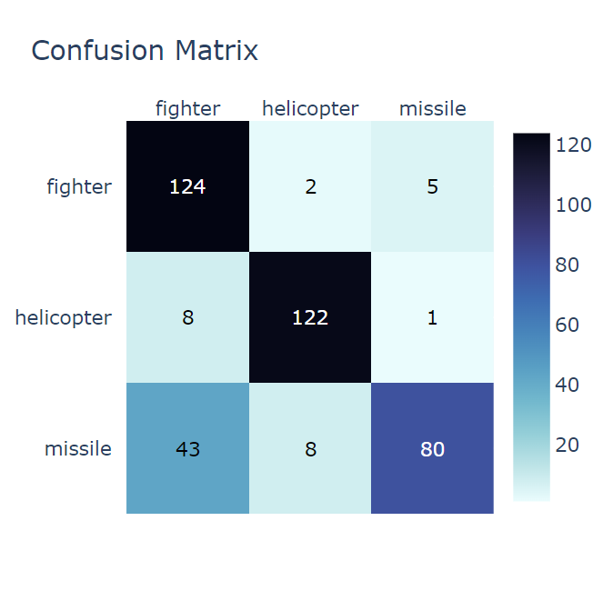

This classification report presents the evaluation metrics for a machine learning model that classifies data into three categories: fighter, helicopter, and missile. The metrics include precision, recall, f1-score, and support, which are key performance measures in classification tasks.

## Key Metrics:

- Precision: Measures the proportion of true positive predictions out of all positive predictions made by the model. High precision indicates that the model makes few false positive errors.
- Recall: Measures the proportion of true positives out of all actual positives in the dataset. High recall indicates that the model can detect most of the actual positive instances, meaning it has few false negatives.
- F1-score: The harmonic mean of precision and recall. It provides a single score that balances both concerns, especially useful when precision and recall are not balanced.
- Support: The number of actual occurrences of each class in the dataset.

## Breakdown by Class:

**Fighter:**

- Precision: 0.71 - The model correctly identified 71% of the fighter class instances from all predicted fighter instances.
- Recall: 0.95 - The model identified 95% of the actual fighter instances, showing it is good at finding them.
- F1-score: 0.81 - This combines precision and recall, indicating a good balance between the two.
- Support: 131 - There were 131 actual fighter instances in the dataset.

**Helicopter:**

- Precision: 0.92 - 92% of the predicted helicopter instances were correct.
- Recall: 0.93 - The model correctly identified 93% of all actual helicopter instances.
- F1-score: 0.93 - Strong balance between precision and recall.
- Support: 131 - There were 131 actual helicopter instances.

**Missile:**

- Precision: 0.93 - 93% of the predicted missile instances were correct.
- Recall: 0.61 - The model identified only 61% of the actual missile instances, indicating it missed many missiles.
- F1-score: 0.74 - The lower recall reduces the F1 score for missiles.
- Support: 131 - There were 131 actual missile instances.

**Overall Model Performance:**

- Accuracy: 83% - The model correctly classified 83% of the total instances across all classes. **Macro Average:**
- Precision: 0.85 - On average, 85% of the predictions were correct across all classes.
- Recall: 0.83 - The model correctly identified 83% of all instances on average.
- F1-score: 0.83 - A balanced score indicating overall performance across classes. **Weighted Average:** This average takes into account the number of instances in each class (support) when calculating precision, recall, and F1-score:
- Precision: 0.85
- Recall: 0.83
- F1-score: 0.83

## Observations:

The model performs well on helicopter (with precision, recall, and F1-score all in the 0.90s). Fighter class shows lower precision but very high recall, meaning the model correctly identifies most fighters, but it also mistakenly classifies other objects as fighters. The missile class has high precision but poor recall, meaning the model identifies missiles well when it does so, but misses many actual missiles (resulting in a lower recall and F1-score). In summary, the model performs fairly well overall, but it struggles with identifying the missile class accurately, which could indicate a need for further refinement in the classification of missiles.

```python
print(classification_report(y_true, y_pred, target_names=test_generator.class_indices.keys()))
```

```
              precision    recall  f1-score   support

     fighter       0.71      0.95      0.81       131
  helicopter       0.92      0.93      0.93       131
     missile       0.93      0.61      0.74       131

    accuracy                           0.83       393
   macro avg       0.85      0.83      0.83       393
weighted avg       0.85      0.83      0.83       393
```

```python
errors = pd.DataFrame({'y_true': y_true, 'y_pred': y_pred}, index=test_generator.filenames)
errors
```

|  | y_true | y_pred |
| --- | --- | --- |
| fighter/00000011.jpg | 0 | 0 |
| fighter/00000050.jpg | 0 | 0 |
| fighter/00000062.jpg | 0 | 0 |
| fighter/00000064.jpg | 0 | 0 |
| fighter/00000069.jpg | 0 | 0 |
| ... | ... | ... |
| missile/00001392.png | 2 | 2 |
| missile/00001394.png | 2 | 0 |
| missile/00001404.jpg | 2 | 1 |
| missile/00001411.jpg | 2 | 2 |
| missile/00001415.png | 2 | 2 |

393 rows × 2 columns

```python
errors['is_incorrect'] = np.where(errors['y_true'] != errors['y_pred'], 1, 0)
```

```python
errors
```

|  | y_true | y_pred | is_incorrect |
| --- | --- | --- | --- |
| fighter/00000011.jpg | 0 | 0 | 0 |
| fighter/00000050.jpg | 0 | 0 | 0 |
| fighter/00000062.jpg | 0 | 0 | 0 |
| fighter/00000064.jpg | 0 | 0 | 0 |
| fighter/00000069.jpg | 0 | 0 | 0 |
| ... | ... | ... | ... |
| missile/00001392.png | 2 | 2 | 0 |
| missile/00001394.png | 2 | 0 | 1 |
| missile/00001404.jpg | 2 | 1 | 1 |
| missile/00001411.jpg | 2 | 2 | 0 |
| missile/00001415.png | 2 | 2 | 0 |

393 rows × 3 columns

```python
errors[errors['is_incorrect'] == 1].index
```

```
Index(['fighter/00000388.jpg', 'fighter/00000479.jpg', 'fighter/00000615.jpg',
       'fighter/00000677.jpg', 'fighter/00000878.jpg', 'fighter/00000907.jpg',
       'fighter/00001169.jpg', 'helicopter/00000308.jpg',
       'helicopter/00000582.jpg', 'helicopter/00000712.jpg',
       'helicopter/00000767.jpg', 'helicopter/00000768.jpg',
       'helicopter/00001157.jpg', 'helicopter/00001399.jpg',
       'helicopter/00001428.jpg', 'helicopter/00001457.jpg',
       'missile/00000013.jpg', 'missile/00000044.jpg', 'missile/00000056.png',
       'missile/00000100.jpg', 'missile/00000139.jpg', 'missile/00000140.jpg',
       'missile/00000142.jpg', 'missile/00000215.jpg', 'missile/00000287.jpg',
       'missile/00000292.jpg', 'missile/00000300.jpg', 'missile/00000359.jpg',
       'missile/00000400.jpg', 'missile/00000428.png', 'missile/00000451.jpg',
       'missile/00000475.jpg', 'missile/00000477.jpg', 'missile/00000518.jpg',
       'missile/00000528.jpg', 'missile/00000530.jpg', 'missile/00000545.jpg',
       'missile/00000575.jpg', 'missile/00000586.jpg', 'missile/00000600.jpg',
       'missile/00000616.jpg', 'missile/00000626.jpg', 'missile/00000628.jpg',
       'missile/00000672.jpg', 'missile/00000686.jpg', 'missile/00000712.jpg',
       'missile/00000755.jpg', 'missile/00000777.jpg', 'missile/00000974.jpg',
       'missile/00000991.jpg', 'missile/00001017.jpg', 'missile/00001049.jpg',
       'missile/00001050.jpg', 'missile/00001107.jpg', 'missile/00001117.JPG',
       'missile/00001123.jpg', 'missile/00001129.jpg', 'missile/00001166.jpg',
       'missile/00001225.jpg', 'missile/00001288.jpg', 'missile/00001328.jpg',
       'missile/00001364.jpg', 'missile/00001368.jpg', 'missile/00001377.jpg',
       'missile/00001389.jpg', 'missile/00001394.png', 'missile/00001404.jpg'],
      dtype='object')
```

```
(-0.5, 639.5, 359.5, -0.5)
```

[figure not shown]

```python
img_path = os.path.join(test_helicopter_dir, '00001457.jpg')

img = image.load_img(img_path)

plt.figure(figsize=(10, 10))
plt.imshow(img)
plt.grid(False)
plt.axis(False)
```